# BROCODE Summary Statistics

BUS696 Final Project v7

Aaron Willis, Cannon Brooke, Joshua Henderson, Ryan Radcliff

```r
getwd()
```

```
[1] "C:/Users/cabrooke/Documents/GitHub/BROCODE_Final_Project"
```

```r
library('scales')
```

## Part 1 - Final Project Cleaning and Summary Statistics

1a) Loading data

```r
avg <- read.csv(here::here("final_project", "yr.csv"),
                 stringsAsFactors = FALSE,
                 strip.white = TRUE,
                 na.strings = "")
```

[output not shown]

1b) Fixing the wonky DOB & Data cleanup

[output not shown]

[output cut: 990 more lines]

```r
#checking for duplicates N >1 indicates a records values are in the file twice
dataclean %>% group_by(ID) %>% count() %>% arrange(desc(n))

#checking for duplicates N >1 indicates a records values are in the file twice
dataclean %>% group_by(ID) %>% count() %>% arrange(desc(n))
```

| ID | n |
| --- | --- |
| 696 | 4 |
| 1198 | 4 |
| 446007 | 4 |
| 634 | 3 |
| 692 | 3 |
| 1737 | 3 |
| 1878 | 3 |
| 10090 | 3 |
| 197220 | 3 |
| 357580 | 3 |

[output cut: 990 more lines]

```r
dataclean <- unique(dataclean)
#n = 1 no ID with multiple records cleaned of dupes
dataclean %>% group_by(ID) %>% count() %>% arrange(desc(n))
```

| ID | n |
| --- | --- |
| 1 | 1 |
| 2 | 1 |
| 3 | 1 |
| 7 | 1 |
| 8 | 1 |
| 9 | 1 |
| 10 | 1 |
| 12 | 1 |
| 14 | 1 |
| 15 | 1 |

[output cut: 990 more lines]

1d Creating many many factor variables

1e Cleaning format on Conferral dates, Last Contact By Anyone, Household First Gift Date Then turning them into aged quantities…

DonorSegment Analysis

| Donor Segment | Count | Mean HH Lifetime Giving |
| --- | --- | --- |
| NA | 231974 | $0.00 |
| Lost Donor | 69718 | $4,954.47 |
| Lapsed Donor | 11193 | $10,069.79 |
| Current Donor | 5603 | $90,638.32 |
| Lapsing Donor | 3862 | $16,590.15 |
| At-Risk Donor | 650 | $77,143.93 |

First gift size

|  | Quantile |
| --- | --- |
| 25% | $0.00 |
| 50% | $0.00 |
| 75% | $0.00 |
| 90% | $40.00 |
| 99% | $1,910.06 |

Consecutive giving

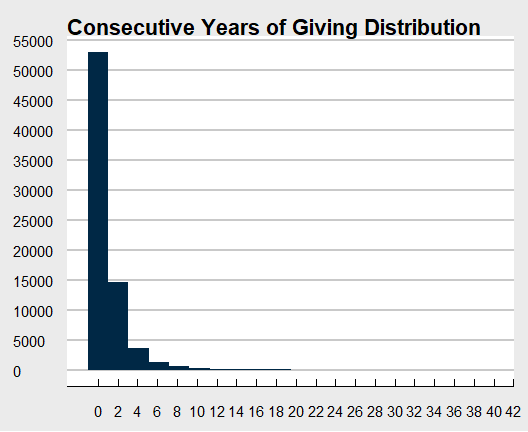

Lifetime giving based on number of children

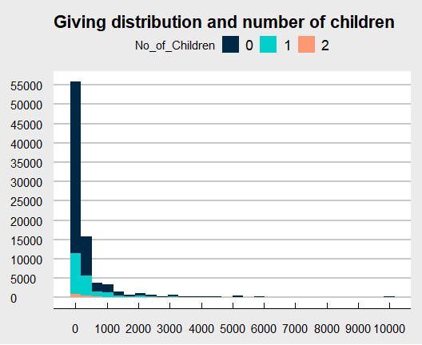

Mean, Median, and Count of Giving in Age Ranges

```r
glimpse(age_range_giving)
```

```
Rows: 11
Columns: 4
$ age_range                     <chr> "10 < 20 year olds", "100+ year olds", "20 < 30 year olds", "30 < 40 year olds", "40 < 50 year olds", "50 < 60 year old~
$ avg_giving                    <dbl> 0.4449699, 19833.4929203, 28.2733731, 391.2236330, 804.2988175, 2780.0863005, 5401.4343359, 11575.1191412, 24358.788472~
$ med_giving                    <dbl> 0.000, 18.475, 0.000, 0.000, 0.000, 0.000, 0.000, 0.000, 10.000, 15.000, 0.000
$ amount_of_people_in_age_range <int> 3990, 2736, 24553, 21021, 16837, 20730, 18227, 12191, 5956, 3889, 192870
```

## Part 2

2a) Plotting average giving by age range

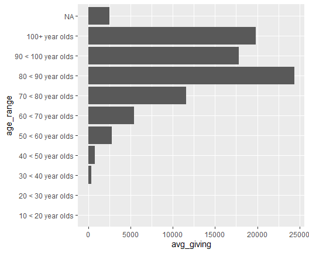

2b) Count of donors based on age range (another way to look at it)

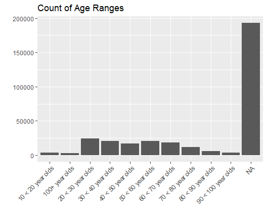

2c) Boxplot of the Age Ranges Against the Lifetime Giving Amounts with a log scale applied - the reason we applied log scale is to resolve issues with visualizations that skew towards large values in our dataset.

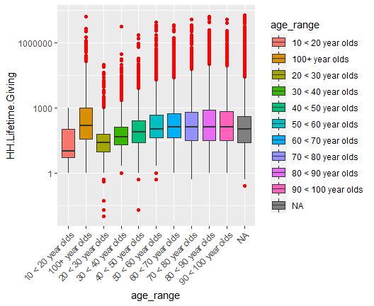

2d) Splitting by age and gender

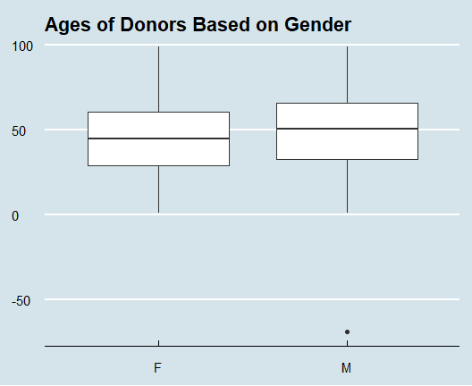

Giving by gender

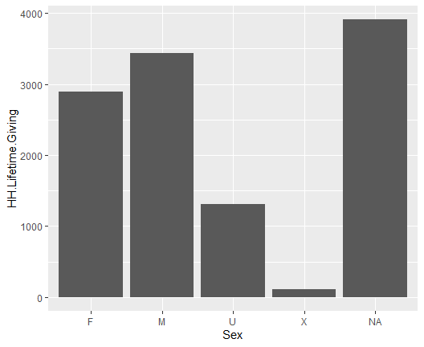

| Sex | age_range | n |
| --- | --- | --- |
| F | 10 < 20 year olds | 2543 |
| F | 100+ year olds | 1285 |
| F | 20 < 30 year olds | 14942 |
| F | 30 < 40 year olds | 12135 |
| F | 40 < 50 year olds | 9650 |
| F | 50 < 60 year olds | 11313 |
| F | 60 < 70 year olds | 8795 |
| F | 70 < 80 year olds | 5469 |
| F | 80 < 90 year olds | 2604 |
| F | 90 < 100 year olds | 1847 |

[output cut: 28 more lines]

2e) Distribution of people in the states that they live.

| Donor's State | Count |
| --- | --- |
| CA | 176487 |
| WA | 7957 |
| TX | 7266 |
| NY | 5659 |
| CO | 5073 |
| AZ | 4925 |
| OR | 4612 |
| FL | 4111 |
| IL | 3681 |
| HI | 3394 |
| PA | 2904 |
| OH | 2754 |
| NV | 2715 |
| MI | 2523 |
| MA | 2473 |
| NJ | 2311 |
| VA | 2158 |
| NC | 2085 |
| GA | 2044 |
| MO | 1889 |
| MN | 1732 |
| MD | 1488 |
| TN | 1443 |
| IN | 1417 |
| CT | 1380 |
| WI | 1330 |
| UT | 1173 |
| OK | 1151 |
| AL | 1120 |
| LA | 1110 |
| ID | 1096 |
| SC | 1076 |
| KY | 1032 |
| KS | 1027 |
| NM | 981 |
| IA | 880 |

2f) Looking at all donors first gift amount. 75% made a first gift of <100.

|  | Quantile |
| --- | --- |
| 25% | 3.8 |
| 50% | 25.0 |
| 75% | 100.0 |
| 90% | 500.0 |
| 99% | 15000.0 |

## Modeling for you

Split data

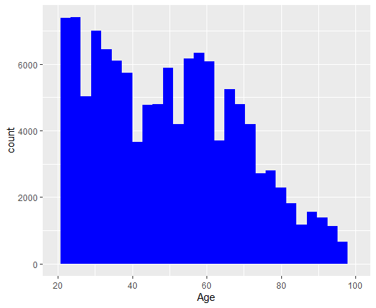

```r
ggplot(data = dataclean, aes(x = Age)) + geom_histogram(fill ="blue")+ xlim(c(20,100))
```

Another Histogram

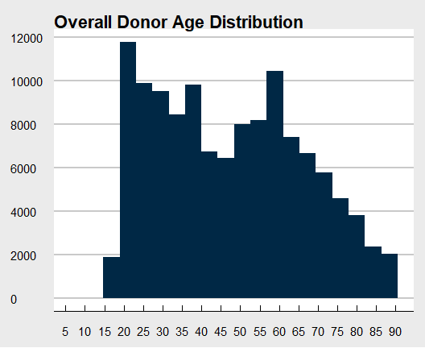

Age distribution by gender

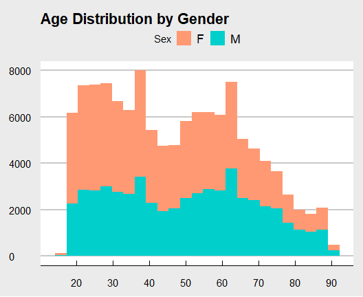

Donor age distribution by marital status

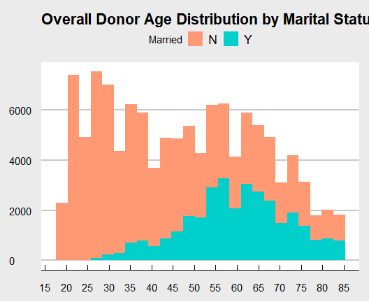

Linear Model

```r
summary(mod2lm)
```

```
Call:
lm(formula = Total.Giving.Years ~ Lifetime.Giving, data = dataclean)

Residuals:
    Min      1Q  Median      3Q     Max
-39.140  -0.553  -0.553  -0.553  39.403

Coefficients:
                     Estimate    Std. Error t value            Pr(>|t|)
(Intercept)     0.55286810251 0.00342309154   161.5 <0.0000000000000002 ***
Lifetime.Giving 0.00000355392 0.00000003325   106.9 <0.0000000000000002 ***
---
Signif. codes:  0 ‘***’ 0.001 ‘**’ 0.01 ‘*’ 0.05 ‘.’ 0.1 ‘ ’ 1

Residual standard error: 1.945 on 322998 degrees of freedom
Multiple R-squared:  0.03416,   Adjusted R-squared:  0.03416
F-statistic: 1.142e+04 on 1 and 322998 DF,  p-value: < 0.00000000000000022
```

MORE MODELS

```r
summary(donor_logit3)
```

```
Call:
glm(formula = hh.lifetime.giving_fct ~ Married_simple + No_of_Children +
    Married_simple + Assignment_flag + Total.Giving.Years, family = "binomial",
    data = data_train)

Deviance Residuals:
   Min      1Q  Median      3Q     Max
-1.121  -0.064  -0.064   0.000   4.087

Coefficients:
                   Estimate Std. Error z value            Pr(>|z|)
(Intercept)        -6.19047    0.06220 -99.518 <0.0000000000000002 ***
Married_simple      5.76350    0.06403  90.013 <0.0000000000000002 ***
No_of_Children     -1.07981    0.02026 -53.285 <0.0000000000000002 ***
Assignment_flag     0.29156    0.13623   2.140              0.0323 *
Total.Giving.Years 25.38198   53.52814   0.474              0.6354
---
Signif. codes:  0 ‘***’ 0.001 ‘**’ 0.01 ‘*’ 0.05 ‘.’ 0.1 ‘ ’ 1

(Dispersion parameter for binomial family taken to be 1)

    Null deviance: 288568  on 242249  degrees of freedom
Residual deviance:  55891  on 242245  degrees of freedom
AIC: 55901

Number of Fisher Scoring iterations: 21
```

RIDGE

```r
print(ridge_fit1$lambda.1se)
```

```
[1] 0.1198608
```

LASSO

```r
#Using cv.glmnet from class

#lasso_fit <- cv.glmnet(dependent ~ indy1 + indy2,
#                       data = data,
                       #Alpha 1 for lasso
#                       alpha = 1)

#print(lasso_fit$lambda.min)
#
#print(lasso_fit$lambda.1se)
```

```r
#coef(lasso_mod)
#Default setting is lambda.1se

#From the book - showing convergence with lambda values
#plot(lasso_mod$glmnet.fit, xvar="lambda")
#abline(v=log(c(lasso_mod$lambda.min, lasso_mod$lambda.1se)), lty=2)
```

```r
#enet_mod <- cva.glmnet(dependent ~ indy1 + indy2,
#                       data = data,
#                       alpha = seq(0,1, by = 0.1))

#print(enet_mod)
#plot(enet_mod)
```

ELASTICNET

```r
minlossplot(enet_mod,
            cv.type = "min")

get_alpha <- function(fit) {
  alpha <- fit$alpha
  error <- sapply(fit$modlist,
                  function(mod) {min(mod$cvm)})
  alpha[which.min(error)]
}

get_model_params <- function(fit) {
  alpha <- fit$alpha
  lambdaMin <- sapply(fit$modlist, `[[`, "lambda.min")
  lambdaSE <- sapply(fit$modlist, `[[`, "lambda.1se")
  error <- sapply(fit$modlist, function(mod) {min(mod$cvm)})
  best <- which.min(error)
  data.frame(alpha = alpha[best], lambdaMin = lambdaMin[best],
             lambdaSE = lambdaSE[best], eror = error[best])
}

best_alpha <- get_alpha(enet_mod)
print(best_alpha)
get_model_params(enet_mod)

best_mod <- enet_mod$modlist[[which(enet_mod$alpha == best_alpha)]]

print(best_mod)
```

[output not shown]

Ridges plot - could be useful for plotting donations vs donor segment

```r
library('ggridges')

summary(data_train$variable)

ggplot(data_train, aes(x = var1, y = var2)) + geom_density_ridges(rel_min_height = 0.005) + xlim(c(0, 400)) +
      ggtitle("Title")
```

[output not shown]

Random Forest

```r
library('randomForest')

rf_fit_donor <- randomForest(dependent ~ .,
                       data = data_train,
                       type = classification,
                       mtry = 7,
                       na.action = na.roughfix,
                       ntree = 200,
                       importance=TRUE
                       )

print(rf_fit_donor)
```

[output not shown]

```r
varImpPlot(rf_fit_donor, sort = TRUE,
           n.var = 5,
           type = 2, class = NULL, scale = TRUE,
           main = deparse(substitute(rf_fit_donor)))
```

[output not shown]

```r
library('randomForestExplainer')

plot_min_depth_distribution(
  rf_fit_donor,
  k = 10,
  min_no_of_trees = 0,
  mean_sample = "top_trees",
  mean_scale = FALSE,
  mean_round = 2,
  main = "Distribution of minimal depth and its mean"
)
```

[output not shown]